# Doing Maths Symbolically: R as a Computer Algebra System (CAS)

Source: https://blog.ephorie.de/doing-maths-symbolically-r-as-a-computer-algebra-system-cas

When I first saw the Computer Algebra System Mathematica in the nineties I was instantly fascinated by it: you could not just calculate things with it but solve equations, simplify, differentiate and integrate expressions and even solve simple differential equations… not just numerically but symbolically! It helped me a lot during my studies at the university back then. Normally you cannot do this kind of stuff with R but fear not, there is, of course, a package for that!

There are many so-called Computer Algebra Systems (CAS) out there, commercial but also open-source. One very mature one is called YACAS (for Yet Another Computer Algebra System). You find the documentation here: Yacas Documentation (many of the following examples are taken from there).

You can use the full power of it in R by installing the Ryacas package from CRAN. You can use Yacas commands directly by invoking the yac_str function, the as_r function converts the output to R. Let us first simplify a mathematical expression:

```r
library(Ryacas)
as_r(yac_str("Simplify(a*b*a^2/b-a^3)"))
```

```
## [1] 0
```

$a*b*a^2/b-a^3$

```r
as_r(yac_str("Solve(a+x*y==z,x)"))
```

```
## [1] "x==-(a-z)/y"
```

$a+x*y==z$

```r
as_r(yac_str("Expand((x-2)^20)"))
```

```
## expression(x^20 - 40 * x^19 + 760 * x^18 - 9120 * x^17 + 77520 *
##     x^16 - 496128 * x^15 + 2480640 * x^14 - 9922560 * x^13 +
##     32248320 * x^12 - 85995520 * x^11 + 189190144 * x^10 - 343982080 *
##     x^9 + 515973120 * x^8 - 635043840 * x^7 + 635043840 * x^6 -
##     508035072 * x^5 + 317521920 * x^4 - 149422080 * x^3 + 49807360 *
##     x^2 - 10485760 * x + 1048576)
```

$(x-2)^{20}$

To demonstrate how easily the results can be integrated into R let us do some curve sketching on a function. First, we define two helper function for converting an expression into a function (which can then be used to plot it) and for determining the derivative of order n of some function (we redefine the D function for that):

```r
as_function <- function(expr) {
  as.function(alist(x =, eval(parse(text = expr))))
}

# redefine D function
D <- function(eq, order = 1) {
  yac_str(paste("D(x,", order, ")", eq))
}
```

Now, we define the function (in this case a simple polynomial $2x^3 - 3x^2 + 4x - 5$), determine the first and second derivatives symbolically and plot everything:

```r
xmin <- -5
xmax <- 5

eq <- "2*x^3 - 3*x^2 + 4*x - 5"
eq_f <- as_function(eq)
curve(eq_f, xmin, xmax, ylab = "y(x)")
abline(h = 0, lty = 2)
abline(v = 0, lty = 2)

D_eq <- D(eq)
D_eq
```

```
## [1] "6*x^2-6*x+4"
```

```r
## [1] "6*x^2-6*x+4"

D_eq_f <- as_function(D_eq)
curve(D_eq_f, xmin, xmax, add = TRUE, col = "blue")

D2_eq <- D(eq, 2)
D2_eq
```

```
## [1] "12*x-6"
```

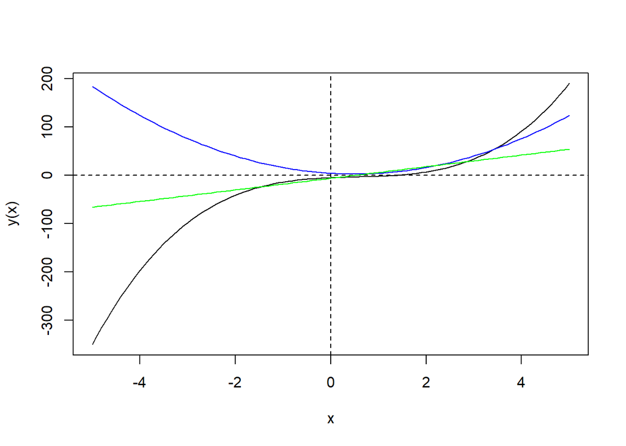

```r
## [1] "12*x-6"

D2_eq_f <- as_function(D2_eq)
curve(D2_eq_f, xmin, xmax, add = TRUE, col = "green")
```

Impressive, isn’t it! Yacas can also determine limits and integrals:

```r
# determine limits
yac_str("Limit(x,0) 1/x")
```

```
## [1] "Undefined"
```

```r
## [1] "Undefined"

yac_str("Limit(x,0,Left) 1/x")
```

```
## [1] "-Infinity"
```

```r
## [1] "-Infinity"

yac_str("Limit(x,0,Right) 1/x")
```

```
## [1] "Infinity"
```

```r
## [1] "Infinity"

# integration
yac_str("Integrate(x) Cos(x)")
```

```
## [1] "Sin(x)"
```

```r
## [1] "Sin(x)"

yac_str("Integrate(x,a,b) Cos(x)")
```

```
## [1] "Sin(b)-Sin(a)"
```

```r
## [1] "Sin(b)-Sin(a)"
```

As an example, we can prove in no-time that the famous approximation $\pi \approx \frac{22}{7}$ is actually too big (more details can be found here: Proof that 22/7 exceeds $\pi$):

```r
yac_str("Integrate(x,0,1) x^4*(1-x)^4/(1+x^2)")
```

```
## [1] "22/7-Pi"
```

And, as the grand finale of this post, Yacas is even able to solve ordinary differential equations symbolically! Let us first take the simplest of them all:

```r
as_r(yac_str("OdeSolve(y'' - 4*y == 0)"))
```

```
## expression(C252 * exp(2 * x) + C256 * exp(-2 * x))
```